# ProjectQ2

Anson Poon Ka Nok

2023-06-24

# Q2

```r
boston <- read.csv('boston_fixed.csv' ) # read the csv file
dt <- na.omit(boston) # omit any missing value
dt = subset(dt, select = -c(X) ) # delete the column 'x'
head(dt)
```

|  | CRIM | ZN | INDUS | CHAS | NOX | RM | AGE | DIS | RAD | TAX | PTRATIO | LSTAT | MEDV |
| --- | --- | --- | --- | --- | --- | --- | --- | --- | --- | --- | --- | --- | --- |
| 1 | 0.00632 | 18 | 2.31 | 0 | 0.538 | 6.575 | 65.2 | 4.0900 | 1 | 296 | 15.3 | 4.98 | 24.0 |
| 2 | 0.02731 | 0 | 7.07 | 0 | 0.469 | 6.421 | 78.9 | 4.9671 | 2 | 242 | 17.8 | 9.14 | 21.6 |
| 3 | 0.02729 | 0 | 7.07 | 0 | 0.469 | 7.185 | 61.1 | 4.9671 | 2 | 242 | 17.8 | 4.03 | 34.7 |
| 4 | 0.03237 | 0 | 2.18 | 0 | 0.458 | 6.998 | 45.8 | 6.0622 | 3 | 222 | 18.7 | 2.94 | 33.4 |
| 5 | 0.06905 | 0 | 2.18 | 0 | 0.458 | 7.147 | 54.2 | 6.0622 | 3 | 222 | 18.7 | 5.33 | 36.2 |
| 6 | 0.02985 | 0 | 2.18 | 0 | 0.458 | 6.430 | 58.7 | 6.0622 | 3 | 222 | 18.7 | 5.21 | 28.7 |

# Q2.1 Exploreatory Data Analysis

#### Do the EDA on dt, use different plots to indicate the relationship between outcome variable (MEDV) and other predictors

```r
skimr::skim(dt) #display the summary table of variables
```

Data summary

| Name | dt |
| --- | --- |
| Number of rows | 506 |
| Number of columns | 13 |
| _______________________ |  |
| Column type frequency: |  |
| numeric | 13 |
| ________________________ |  |
| Group variables | None |

**Variable type: numeric**

| skim_variable | n_missing | complete_rate | mean | sd | p0 | p25 | p50 | p75 | p100 | hist |
| --- | --- | --- | --- | --- | --- | --- | --- | --- | --- | --- |
| CRIM | 0 | 1 | 3.61 | 8.60 | 0.01 | 0.08 | 0.26 | 3.68 | 88.98 | ▇▁▁▁▁ |
| ZN | 0 | 1 | 11.36 | 23.32 | 0.00 | 0.00 | 0.00 | 12.50 | 100.00 | ▇▁▁▁▁ |
| INDUS | 0 | 1 | 11.14 | 6.86 | 0.46 | 5.19 | 9.69 | 18.10 | 27.74 | ▇▆▁▇▁ |
| CHAS | 0 | 1 | 0.07 | 0.25 | 0.00 | 0.00 | 0.00 | 0.00 | 1.00 | ▇▁▁▁▁ |
| NOX | 0 | 1 | 0.55 | 0.12 | 0.38 | 0.45 | 0.54 | 0.62 | 0.87 | ▇▇▆▅▁ |
| RM | 0 | 1 | 6.28 | 0.70 | 3.56 | 5.89 | 6.21 | 6.62 | 8.78 | ▁▂▇▂▁ |
| AGE | 0 | 1 | 68.57 | 28.15 | 2.90 | 45.02 | 77.50 | 94.07 | 100.00 | ▂▂▂▃▇ |
| DIS | 0 | 1 | 3.80 | 2.11 | 1.13 | 2.10 | 3.21 | 5.19 | 12.13 | ▇▅▂▁▁ |
| RAD | 0 | 1 | 9.55 | 8.71 | 1.00 | 4.00 | 5.00 | 24.00 | 24.00 | ▇▂▁▁▃ |
| TAX | 0 | 1 | 408.24 | 168.54 | 187.00 | 279.00 | 330.00 | 666.00 | 711.00 | ▇▇▃▁▇ |
| PTRATIO | 0 | 1 | 18.46 | 2.16 | 12.60 | 17.40 | 19.05 | 20.20 | 22.00 | ▁▃▅▅▇ |
| LSTAT | 0 | 1 | 12.65 | 7.14 | 1.73 | 6.95 | 11.36 | 16.96 | 37.97 | ▇▇▅▂▁ |
| MEDV | 0 | 1 | 22.53 | 9.20 | 5.00 | 17.02 | 21.20 | 25.00 | 50.00 | ▂▇▅▁▁ |

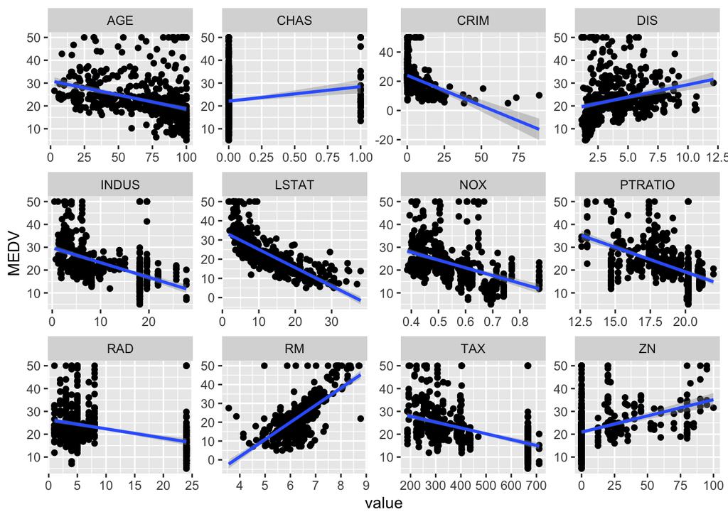

```r
 # describe all the relationship between outcome variable against predictors in scatter plot
dt %>%
  pivot_longer(-MEDV) %>%
  ggplot(aes(value, MEDV)) +
  geom_point() +
  facet_wrap(~name, scales = "free") +
  geom_smooth(method = lm)
```

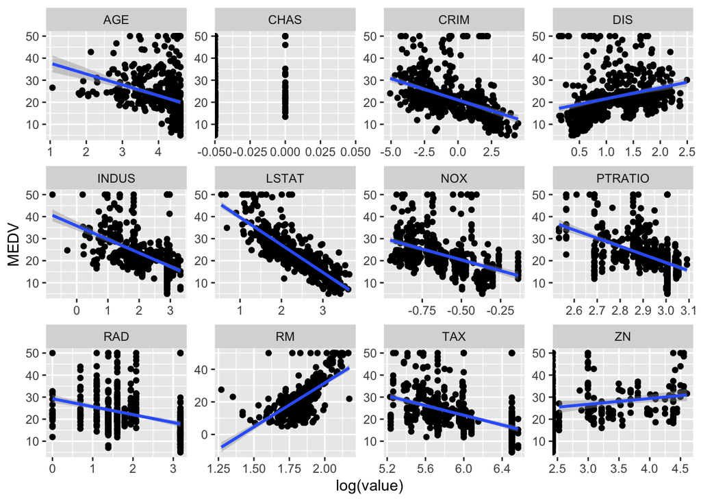

```r
# try the log scale on the predictors
dt %>%
  pivot_longer(-MEDV) %>%
  ggplot(aes(log(value), MEDV)) +
  geom_point() +
  facet_wrap(~name, scales = "free") +
  geom_smooth(method = lm)
```

#### From the scatter plot that show all the relationship between MEDV and all the predictors in dt, most of them have a negative relationship with MEDV, they are AGE, CRIM, INDUS, LSTAT, NOX, PTRATIO, RAD and TAX. If these variables increase in value, the median value of homes decrease. Four of them show a positive relationship with MEDV, they are CHAS, DIS, RM and ZN. The median value of homes will increase with the inccrease in these variables. Among all the plots, LSTAT and RM have shown a strong linear relationship with MEDV. Some variables in scatter plot with log scale show a more linear relationship, it can be good for the model prediction afterward.

#### Relationship between CHAS and MEDV

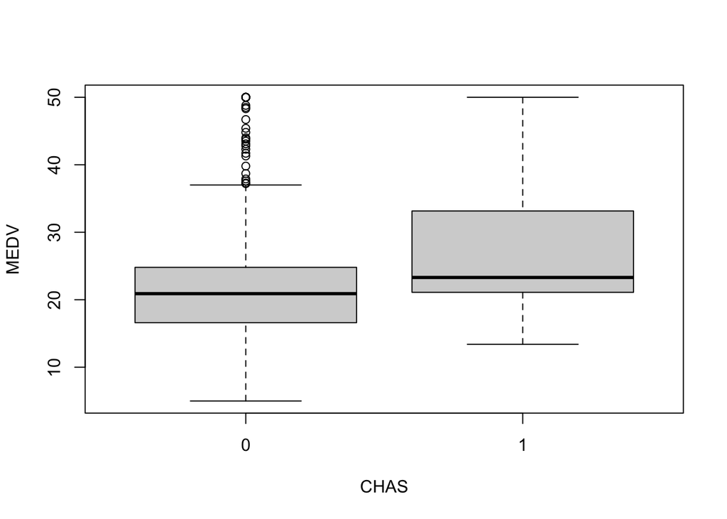

```r
boxplot(dt$MEDV ~ dt$CHAS, xlab = "CHAS", ylab = "MEDV") # box plot to show more information of MEDV and CHAS
```

#### From the boxplot, it shows that if Boston tracts bounds river, the median value of home will increase.

### Relationship between RAD and MEDV

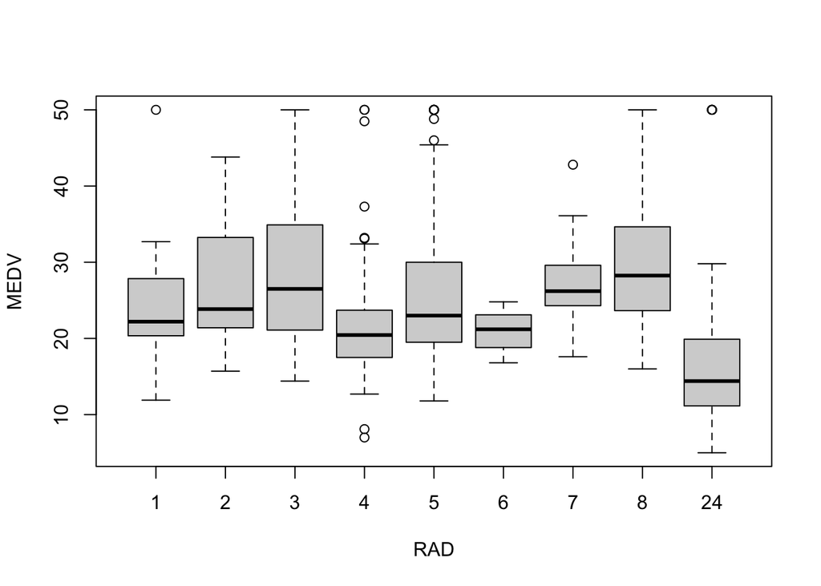

```r
boxplot(dt$MEDV ~ dt$RAD, xlab = "RAD", ylab = "MEDV") ## box plot to show more information of MEDV and RAD
```

#### From the boxplot, if the index of accessibility of radial highways is 24, the median values of homes drop. Other than that, the median value is all similar.

#### Correlation check of all variables

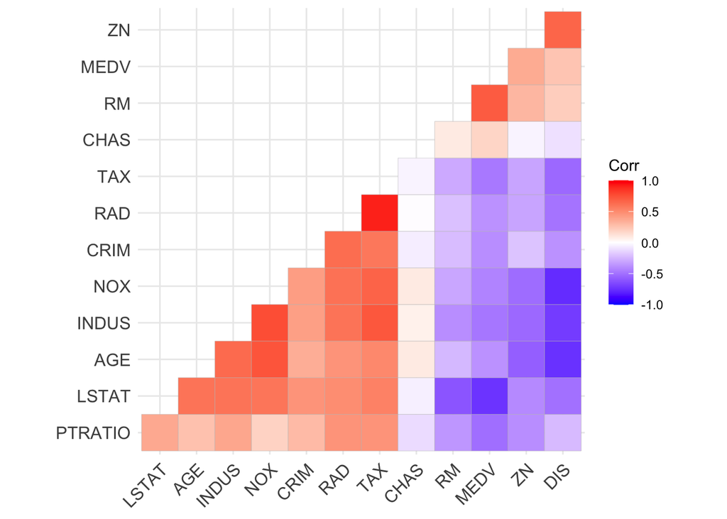

```r
dt_corr <- cor(dt)
ggcorrplot::ggcorrplot(dt_corr, hc.order = TRUE, type = "lower") # heatmap of correlation between all variables
```

#### The heatmap of correlation show that LSTAT and RM have a strong correlation with MEDV.

#### Distribution of outcome variable

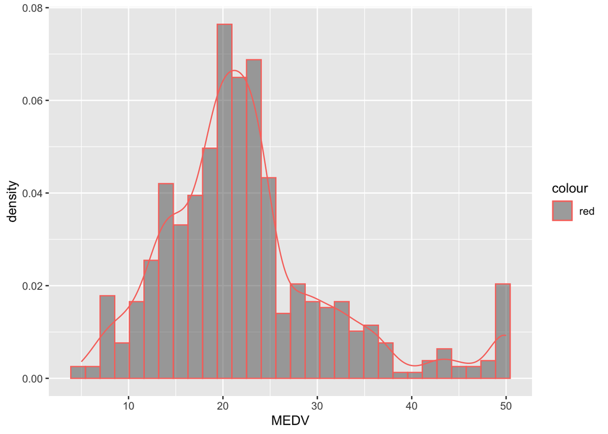

```r
# plot a histogram
ggplot(dt, aes(x=MEDV, color="red")) +
geom_histogram(aes(y=..density..), position="identity", alpha=0.5)+
geom_density(alpha=0.5)
```

#### The histogram of MEDV show that MEDV has a right-skewed distribution.

# 2.2 Model Selection

#### Since we want to know how will the median value of homes be effected by certain variables, and in what extend, therefore, a multiple linear regression model is used. The assumptions here are the linearly, homoskedasticity, independent of errors, normally distributed errors and independence of the predictors.

```r
dt_lm <- lm(MEDV ~. , data = dt) # regression using all predictors
summary(dt_lm)
```

```
##
## Call:
## lm(formula = MEDV ~ ., data = dt)
##
## Residuals:
##      Min       1Q   Median       3Q      Max
## -15.1304  -2.7673  -0.5814   1.9414  26.2526
##
## Coefficients:
##               Estimate Std. Error t value Pr(>|t|)
## (Intercept)  41.617270   4.936039   8.431 3.79e-16 ***
## CRIM         -0.121389   0.033000  -3.678 0.000261 ***
## ZN            0.046963   0.013879   3.384 0.000772 ***
## INDUS         0.013468   0.062145   0.217 0.828520
## CHAS          2.839993   0.870007   3.264 0.001173 **
## NOX         -18.758022   3.851355  -4.870 1.50e-06 ***
## RM            3.658119   0.420246   8.705  < 2e-16 ***
## AGE           0.003611   0.013329   0.271 0.786595
## DIS          -1.490754   0.201623  -7.394 6.17e-13 ***
## RAD           0.289405   0.066908   4.325 1.84e-05 ***
## TAX          -0.012682   0.003801  -3.337 0.000912 ***
## PTRATIO      -0.937533   0.132206  -7.091 4.63e-12 ***
## LSTAT        -0.552019   0.050659 -10.897  < 2e-16 ***
## ---
## Signif. codes:  0 '***' 0.001 '**' 0.01 '*' 0.05 '.' 0.1 ' ' 1
##
## Residual standard error: 4.798 on 493 degrees of freedom
## Multiple R-squared:  0.7343, Adjusted R-squared:  0.7278
## F-statistic: 113.5 on 12 and 493 DF,  p-value: < 2.2e-16
```

#### From the model dt_lm, INDUS and AGE are not significant predictors, create a new model that ignore these two predictors.

```r
dt_lm2 <- lm(MEDV ~ CRIM + ZN + CHAS + NOX + RM + DIS + RAD + TAX + PTRATIO + LSTAT, data = dt)
summary(dt_lm2) #regression omitting INDUS and AGE
```

```
##
## Call:
## lm(formula = MEDV ~ CRIM + ZN + CHAS + NOX + RM + DIS + RAD +
##     TAX + PTRATIO + LSTAT, data = dt)
##
## Residuals:
##      Min       1Q   Median       3Q      Max
## -15.1814  -2.7625  -0.6243   1.8448  26.3920
##
## Coefficients:
##               Estimate Std. Error t value Pr(>|t|)
## (Intercept)  41.451747   4.903283   8.454 3.18e-16 ***
## CRIM         -0.121665   0.032919  -3.696 0.000244 ***
## ZN            0.046191   0.013673   3.378 0.000787 ***
## CHAS          2.871873   0.862591   3.329 0.000935 ***
## NOX         -18.262427   3.565247  -5.122 4.33e-07 ***
## RM            3.672957   0.409127   8.978  < 2e-16 ***
## DIS          -1.515951   0.187675  -8.078 5.08e-15 ***
## RAD           0.283932   0.063945   4.440 1.11e-05 ***
## TAX          -0.012292   0.003407  -3.608 0.000340 ***
## PTRATIO      -0.930961   0.130423  -7.138 3.39e-12 ***
## LSTAT        -0.546509   0.047442 -11.519  < 2e-16 ***
## ---
## Signif. codes:  0 '***' 0.001 '**' 0.01 '*' 0.05 '.' 0.1 ' ' 1
##
## Residual standard error: 4.789 on 495 degrees of freedom
## Multiple R-squared:  0.7342, Adjusted R-squared:  0.7289
## F-statistic: 136.8 on 10 and 495 DF,  p-value: < 2.2e-16
```

```r
# Test dt_lm and dt_lm2 fitness
AIC(dt_lm, dt_lm2)
```

|  | df | AIC |
| --- | --- | --- |
| dt_lm | 14 | 3037.821 |
| dt_lm2 | 12 | 3033.944 |

#### After delete two insignificant predictors, the model is now better in terms of f-statistic and adjusted r squared, also with a lower AIC. Thus CRIM, ZN, CHAS, NOX, RM, DIS, RAD, TAX, PTRATIO and LSTAT are chosen to be the predictor of the model.

#### From the EDA above, some predictors do not have a linear relationship with MEDV with the original value. After taking log to all predictors, CRIM, NOX, DIS and RAD show a better linear relationship, therefore, use the log value in the transformed regression model.

```r
# Transformation of model
dt_lm_transformed_X <- lm(MEDV ~ log(CRIM) + ZN + log(NOX) + CHAS  + RM + log(DIS) + log(RAD) + log(TAX) + log(PTRATIO) + log(LSTAT), data = dt)
summary(dt_lm_transformed_X)
```

```
##
## Call:
## lm(formula = MEDV ~ log(CRIM) + ZN + log(NOX) + CHAS + RM + log(DIS) +
##     log(RAD) + log(TAX) + log(PTRATIO) + log(LSTAT), data = dt)
##
## Residuals:
##      Min       1Q   Median       3Q      Max
## -14.7609  -2.5067  -0.2093   2.1039  23.8553
##
## Coefficients:
##                Estimate Std. Error t value Pr(>|t|)
## (Intercept)   91.830654   7.941441  11.563  < 2e-16 ***
## log(CRIM)     -0.136926   0.237206  -0.577  0.56403
## ZN             0.001645   0.011650   0.141  0.88778
## log(NOX)     -11.273638   2.253958  -5.002 7.90e-07 ***
## CHAS           2.512329   0.768595   3.269  0.00116 **
## RM             2.740676   0.374146   7.325 9.75e-13 ***
## log(DIS)      -6.350293   0.729034  -8.711  < 2e-16 ***
## log(RAD)       1.941824   0.473485   4.101 4.81e-05 ***
## log(TAX)      -4.826337   0.995835  -4.847 1.68e-06 ***
## log(PTRATIO) -13.552240   1.948585  -6.955 1.12e-11 ***
## log(LSTAT)    -9.171433   0.530082 -17.302  < 2e-16 ***
## ---
## Signif. codes:  0 '***' 0.001 '**' 0.01 '*' 0.05 '.' 0.1 ' ' 1
##
## Residual standard error: 4.277 on 495 degrees of freedom
## Multiple R-squared:  0.788,  Adjusted R-squared:  0.7837
## F-statistic:   184 on 10 and 495 DF,  p-value: < 2.2e-16
```

```r
# test vif of dt_lm_transformed_X
vif(dt_lm_transformed_X)
```

```
##    log(CRIM)           ZN     log(NOX)         CHAS           RM     log(DIS)
##     7.260122     2.037716     5.692867     1.051975     1.907581     4.270869
##     log(RAD)     log(TAX) log(PTRATIO)   log(LSTAT)
##     4.736163     4.300626     1.632971     2.800532
```

#### Since log(CRIM) has a high VIF and is not statistically significant at the 0.05 significance level. Therefore delete it from the transformed model.

```r
dt_lm_transformed_X1 <- lm(MEDV ~ ZN + log(NOX) + CHAS  + RM + log(DIS) + log(RAD) + log(TAX) + log(PTRATIO) + log(LSTAT), data = dt)
summary(dt_lm_transformed_X1)
```

```
##
## Call:
## lm(formula = MEDV ~ ZN + log(NOX) + CHAS + RM + log(DIS) + log(RAD) +
##     log(TAX) + log(PTRATIO) + log(LSTAT), data = dt)
##
## Residuals:
##      Min       1Q   Median       3Q      Max
## -14.6551  -2.5321  -0.2304   2.1025  23.8290
##
## Coefficients:
##                Estimate Std. Error t value Pr(>|t|)
## (Intercept)   92.651040   7.807983  11.866  < 2e-16 ***
## ZN             0.002545   0.011537   0.221  0.82551
## log(NOX)     -11.630837   2.165896  -5.370 1.21e-07 ***
## CHAS           2.513045   0.768078   3.272  0.00114 **
## RM             2.736495   0.373825   7.320 1.01e-12 ***
## log(DIS)      -6.284342   0.719542  -8.734  < 2e-16 ***
## log(RAD)       1.792512   0.396322   4.523 7.64e-06 ***
## log(TAX)      -4.940674   0.975282  -5.066 5.74e-07 ***
## log(PTRATIO) -13.529278   1.946869  -6.949 1.16e-11 ***
## log(LSTAT)    -9.215088   0.524307 -17.576  < 2e-16 ***
## ---
## Signif. codes:  0 '***' 0.001 '**' 0.01 '*' 0.05 '.' 0.1 ' ' 1
##
## Residual standard error: 4.274 on 496 degrees of freedom
## Multiple R-squared:  0.7879, Adjusted R-squared:  0.784
## F-statistic: 204.7 on 9 and 496 DF,  p-value: < 2.2e-16
```

#### Although there are insignificant varibles, the adjusted r-squared incrased, it should imply that the new transformed model is better. Compare two models with AIC test.

```r
AIC(dt_lm_transformed_X, dt_lm_transformed_X1) # Compare AIC of both transformed model
```

|  | df | AIC |
| --- | --- | --- |
| dt_lm_transformed_X | 12 | 2919.594 |
| dt_lm_transformed_X1 | 11 | 2917.934 |

```r
# Compare dt_lm_transformed_X to dt_lm_transformed_X1
anova(dt_lm_transformed_X, dt_lm_transformed_X1)
```

|  | Res.Df | RSS | Df | Sum of Sq | F | Pr(>F) |
| --- | --- | --- | --- | --- | --- | --- |
| 1 | 495 | 9055.946 | NA | NA | NA | NA |
| 2 | 496 | 9062.042 | -1 | -6.09611 | 0.3332147 | 0.5640347 |

#### After comparing both model, dt_lm_transformed_X1 has a lower AIC. The anova result shows a non-significant result (p = 0.564) which suggest dt_lm_transformed_X to be rejected. Therefore I choose dt_lm_transformed_X1 as the best model. Now check the assumptions of the model.

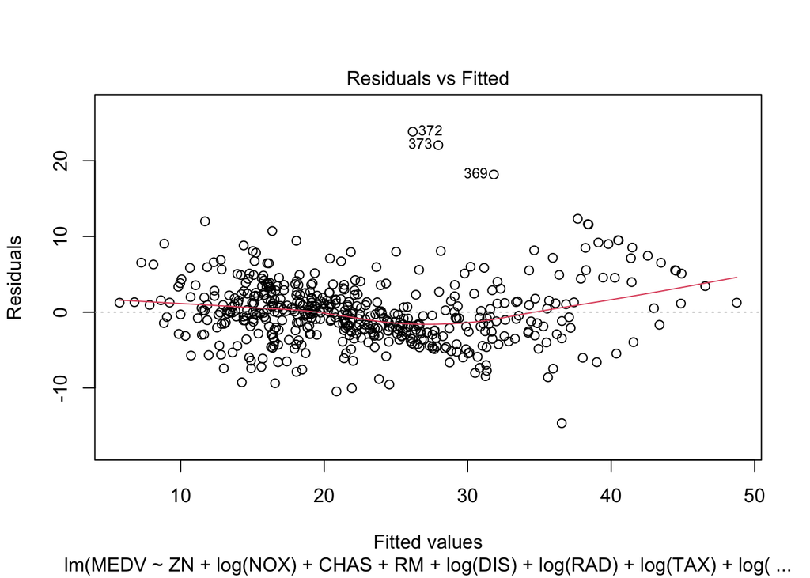

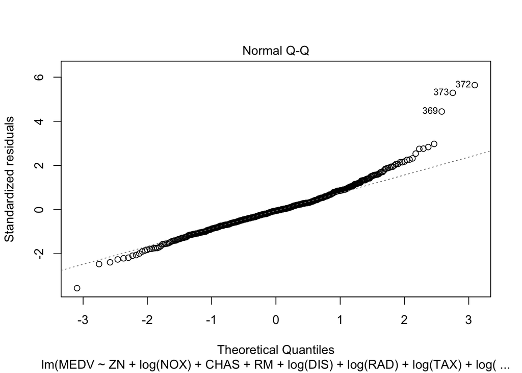

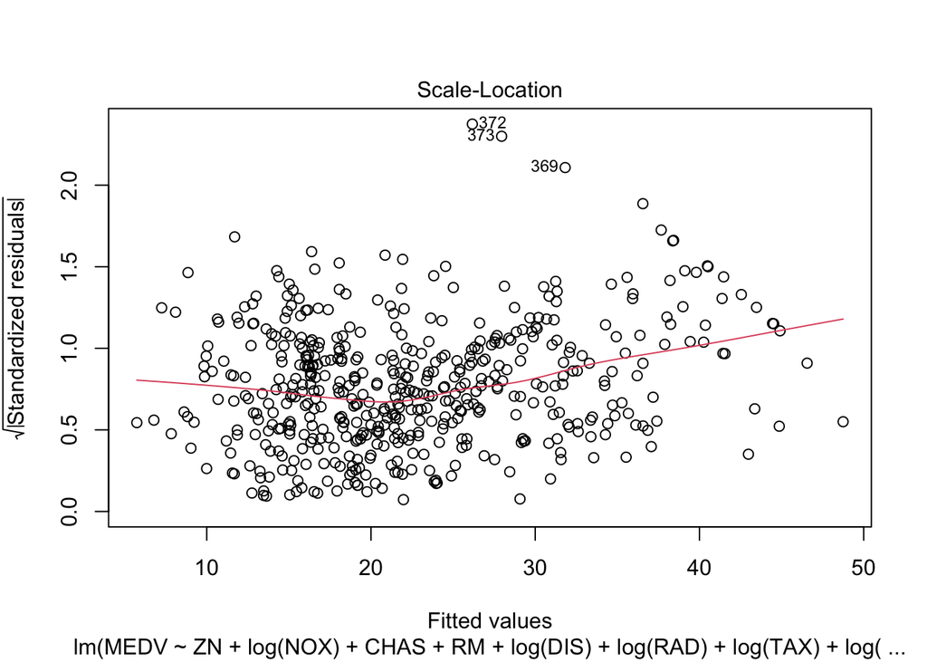

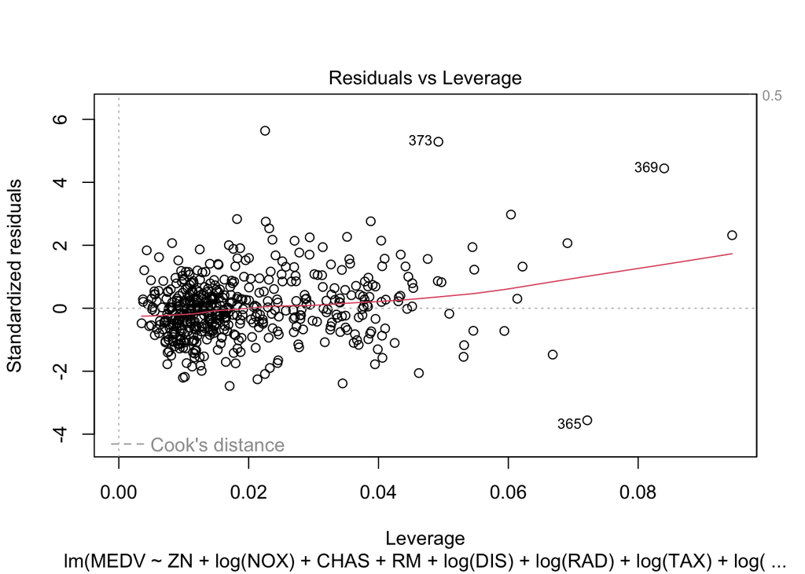

```r
# check assumptions using plot()
plot(dt_lm_transformed_X1)
```

```r
#check multicollinearity of chosen model
vif(dt_lm_transformed_X1)
```

```
##           ZN     log(NOX)         CHAS           RM     log(DIS)     log(RAD)
##     2.001210     5.263790     1.051972     1.906866     4.165978     3.322728
##     log(TAX) log(PTRATIO)   log(LSTAT)
##     4.130485     1.632290     2.743528
```